# Práctica 01

# 1 Instrucciones

### Enunciado

Una agencia de viajes tiene 25 oficinas y desea llevar un resumen de sus gastos anuales en cada oficina.

**Generar una tabla** (Hoja resumen) donde aparezcan resumidos **los gastos en cada oficina** (totales y por empleado)

### Datos

**Datos**

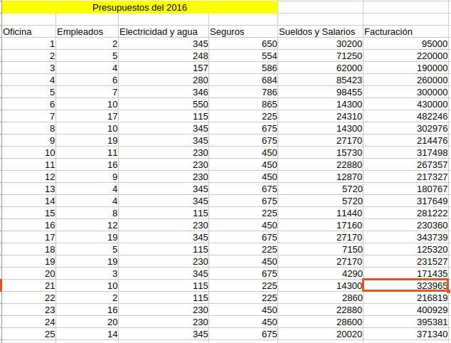

### Solución

**Solución**

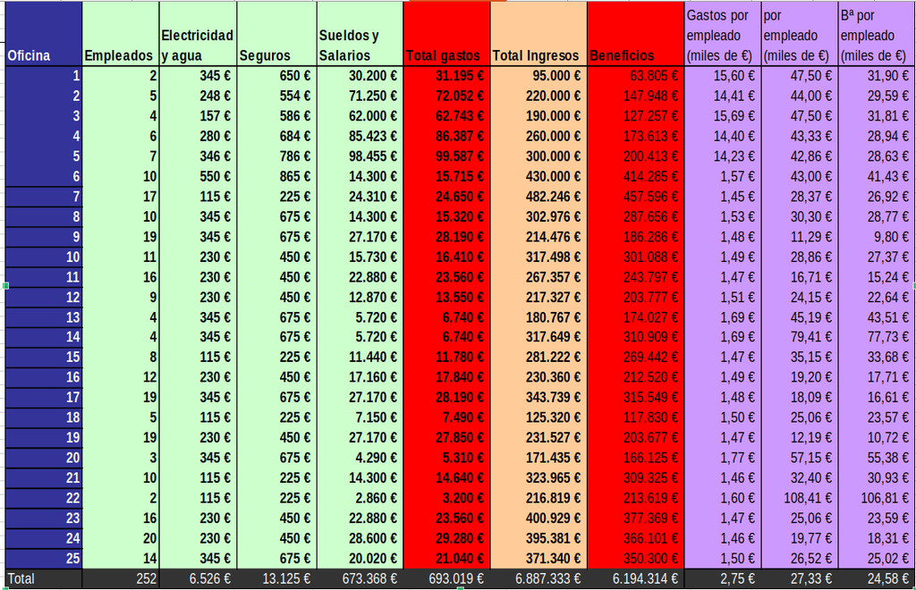

## ¿Qué aprenderemos?

**¿Qué aprenderemos?**

1- Crear / eliminar hojas  
2- Nombrar hojas

3- Hacer referencias relativas a otras celdas

4- Funciones matemáticas simples (suma, división, etc.)

5- Dar formato a celdas y tablas  
- formato número (decimales, etc.)  
- formato fuente  
- tramas, bordes, etc.

**Estrategia**

1. Crear una nueva hoja (worksheet) y ponerle nombre
2. En la nueva hoja copiaremos los datos pero usando una referencia relativa
3. A partir de los datos originales crearemos nuevas columnas con los resultados que nos piden; para ello tendremos que usar varias funciones de Excel
4. Finalmente daremos formato a las celdas

**Datos y solución**

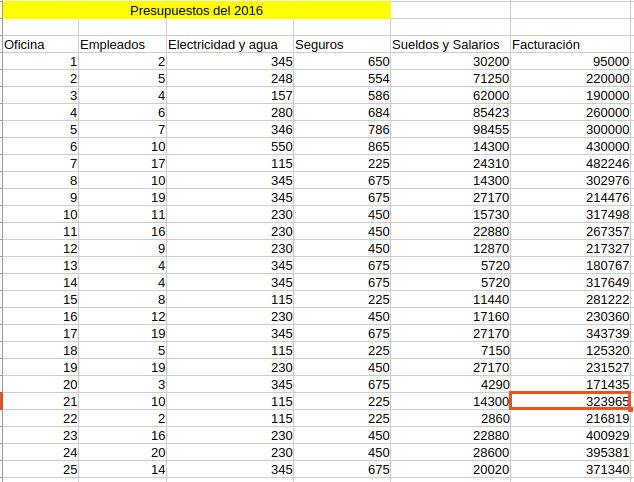

Figure 1

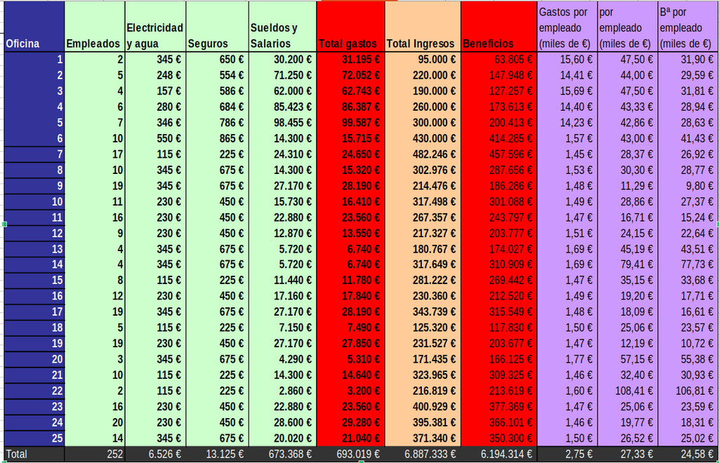

Figure 2

# 2 Resolución

## 2.1 Crear hoja

Caremos una hoja nueva. En ella haremos nuestra solución

A. Seleccione el icono ⊕ en la parte inferior del libro.

B. Alternativamente, puede seleccionar Inicio > Insertar > Insertar hoja

Documentación oficial [aquí](https://support.microsoft.com/es-es/office/insertar-o-eliminar-una-hoja-de-c%C3%A1lculo-19d3d21e-a3b3-4e13-a422-d1f43f1faaf2)

## 2.2 Renombrar hoja

A la nueva hoja le ponemos el nombre “Solución”

A. Alternativamente, haga **clic con el botón derecho** en la pestaña Hoja , seleccione Cambiar nombre y escriba un nombre nuevo.

B. Haga **doble clic** en el nombre de la hoja en la pestaña Hoja para cambiarle el nombre rápidamente.

Documentación oficial [aquí](https://support.microsoft.com/es-es/office/insertar-o-eliminar-una-hoja-de-c%C3%A1lculo-19d3d21e-a3b3-4e13-a422-d1f43f1faaf2)[^1]

## 2.3 Copiar datos

Copiaremos los datos originales en la hoja que hemos creado … pero lo haremos usando referencias: vincularemos datos entre diferentes hojas dentro del mismo libro de Excel.

Para copiar datos usando referencias a otra hoja en Excel, puedes crear una fórmula que comience con el signo = seguido del nombre de la hoja, un signo de exclamación (!) y la celda o rango que deseas copiar. **Por ejemplo**, para copiar la celda A1 de la Hoja1, escribirías =Hoja1!A1 en la celda deseada.

Si el nombre de la hoja contiene espacios, debes encerrarlo entre comillas simples, por ejemplo, ='Nombre de Hoja'!A1

Después nos queda arrastrar hasta que alcancemos todo el rango de los datos originales.

Video explicativo [aquí](https://support.microsoft.com/es-es/office/mover-o-copiar-hojas-de-c%C3%A1lculo-o-los-datos-que-contienen-47207967-bbb2-4e95-9b5c-3c174aa69328)

## 2.4 Creando y rellenando columnas

Tendremos que ir creando columnas con lo que nos pide la práctica

1. **Columna “Total Gastos”** . La hemos de crear después de “Sueldos y Salarios”. Su contenido debe ser la suma total de gastos en cada oficina. Esto lo conseguiremos usando la formula =SUMA(C2:E2).  
   Finalmente nos queda arrastrar para cubrir todo el rango de datos
2. Cambiamos el nombre de la columna “Facturación” a “Total Ingresos”
3. Creamos columna de Beneficios con la formula (=G2-F2) … y arrastramos (o doble clik cuando veamos el símbolo `+`)
4. Creamos 3 columnas de Gastos por empleado con la(s) formula(s): =(F2/B2)/1000, =(G2/B2)/1000, …

## 2.6 Dando formato

- Antes de dar formato a las celdas, insertaremos el símbolo del euro en las cabeceras de las columnas ( Insertar > Símbolo > Símbolo)

### Formato de Celdas

- Podemos dar **formato a las celdas** desde la cinta de opciones: Inicio > Formato … pero a mi me gusta mas usar el **menú contextual** Click derecho → “Formato de celdas”
- Para abrir el **menú contextual** has de: Click derecho → “Formato de celdas”. Al hacerlo, se abrirá una ventana/interfaz donde podemos seleccionar las siguientes opciones:
  - **Número**: donde [podremos elegir la categoría o tipo de datos que estamos usando (lo vemos)
  - **Alineación**: Horizontal, vertical, orientación, …
  - **Fuente**: Tipo, tamaño, color, estilo, …
  - **Bordes**: Estilo y color de líneas
  - **Relleno**: Color de fondo

### Colores del texto y fondo de las celdas

- Color del texto (busca el icono con una A con una línea de color debajo o usa el **menu contextual**)
- Color del fondo (usa el icono que está al lado del anterior)

### Formato de los números

- Decimales , separador de miles etc …

#### Formatos comunes:

- **General**: Formato por defecto
- **Número**: Con separadores de miles
- **Moneda**: $1,234.56
- **Porcentaje**: 15%
- **Fecha**: 15/12/2024
- **Científico**: 1.23E+03

### Bordes de las columnas

- En la tabla hay varios tipo de bordes para las celdas y columnas. Vamos a ello

## EXtensión: Copiador de formatos (Brocha)

Hay varias formas de pegar los formatos:

##### 1. Usando el copiador de formatos (**Brocha**)

- Seleccionar la celda con el formato que quieres copiar
- Haz clic en el botón “Copiador de formato” (icono de brocha) en la pestaña “Inicio”
- Haz clic en la celda (o selecciona el rango) donde quieres aplicar el formato

(**Truco**: puedes hacer doble clic en la brocha para mantenerla activa y aplicar el formato a múltiples rangos. Presiona Esc para desactivarla)

##### 2. Copiar y Pegado especial

- Selecciona y copia la celda (Ctrl + C)
- Selecciona las celdas destino
- Clic derecho → “Pegado especial” → “Formatos” → Aceptar

##### 3. Arrastrar para rellenar formato

- Selecciona la celda con formato que quieres copiar a otras celdas
- Usa el controlador de relleno (cuadrito en la esquina): mientras mantienes presionado Ctrl, arrastra sobre las celdas donde quieres aplicar el formato

##### 4. Crear un estilo personalizado

Es útil si hay un formato que usas frecuentemente:

- Formatea una celda como quieras
- Pestaña “Inicio” → “Estilos de celda” → “Nuevo estilo de celda”
- Dale un nombre y podrás aplicarlo desde el menú de estilos

## Footnotes

[^1]: Es la misma documentación que en 2.1